# Assignment 2- Multiple Regression

Granger Moch and Sam Eckhardt

```r
local({r <- getOption("repos");
       r["CRAN"] <- "http://cran.r-project.org"; options(repos=r)})

install.packages("ISLR")
library(dplyr)
```

```r
library(ggplot2)
library(ISLR)
library(gridExtra)
data(Carseats)
```

# 1 -

Summarize the variables and identify numeric and factor variables.

```r
summary(Carseats)
```

```
##      Sales          CompPrice       Income        Advertising
##  Min.   : 0.000   Min.   : 77   Min.   : 21.00   Min.   : 0.000
##  1st Qu.: 5.390   1st Qu.:115   1st Qu.: 42.75   1st Qu.: 0.000
##  Median : 7.490   Median :125   Median : 69.00   Median : 5.000
##  Mean   : 7.496   Mean   :125   Mean   : 68.66   Mean   : 6.635
##  3rd Qu.: 9.320   3rd Qu.:135   3rd Qu.: 91.00   3rd Qu.:12.000
##  Max.   :16.270   Max.   :175   Max.   :120.00   Max.   :29.000
##    Population        Price        ShelveLoc        Age
##  Min.   : 10.0   Min.   : 24.0   Bad   : 96   Min.   :25.00
##  1st Qu.:139.0   1st Qu.:100.0   Good  : 85   1st Qu.:39.75
##  Median :272.0   Median :117.0   Medium:219   Median :54.50
##  Mean   :264.8   Mean   :115.8                Mean   :53.32
##  3rd Qu.:398.5   3rd Qu.:131.0                3rd Qu.:66.00
##  Max.   :509.0   Max.   :191.0                Max.   :80.00
##    Education    Urban       US
##  Min.   :10.0   No :118   No :142
##  1st Qu.:12.0   Yes:282   Yes:258
##  Median :14.0
##  Mean   :13.9
##  3rd Qu.:16.0
##  Max.   :18.0
```

```r
str(Carseats)
```

```
## 'data.frame':    400 obs. of  11 variables:
##  $ Sales      : num  9.5 11.22 10.06 7.4 4.15 ...
##  $ CompPrice  : num  138 111 113 117 141 124 115 136 132 132 ...
##  $ Income     : num  73 48 35 100 64 113 105 81 110 113 ...
##  $ Advertising: num  11 16 10 4 3 13 0 15 0 0 ...
##  $ Population : num  276 260 269 466 340 501 45 425 108 131 ...
##  $ Price      : num  120 83 80 97 128 72 108 120 124 124 ...
##  $ ShelveLoc  : Factor w/ 3 levels "Bad","Good","Medium": 1 2 3 3 1 1 3 2 3 3 ...
##  $ Age        : num  42 65 59 55 38 78 71 67 76 76 ...
##  $ Education  : num  17 10 12 14 13 16 15 10 10 17 ...
##  $ Urban      : Factor w/ 2 levels "No","Yes": 2 2 2 2 2 1 2 2 1 1 ...
##  $ US         : Factor w/ 2 levels "No","Yes": 2 2 2 2 1 2 1 2 1 2 ...
```

# 2 -

Plot histograms of numeric variables and bar plots for factor variables.

[output not shown]

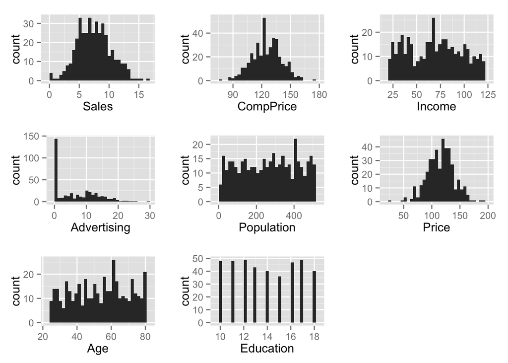

```r
p1= ggplot(Carseats, aes(x=Sales)) + geom_histogram()
p2= ggplot(Carseats, aes(x=CompPrice)) + geom_histogram()
p3= ggplot(Carseats, aes(x=Income)) + geom_histogram()
p4= ggplot(Carseats, aes(x=Advertising)) + geom_histogram()
p5= ggplot(Carseats, aes(x=Population)) + geom_histogram()
p6= ggplot(Carseats, aes(x=Price)) + geom_histogram()
p7= ggplot(Carseats, aes(x=Age)) + geom_histogram()
p8= ggplot(Carseats, aes(x=Education)) + geom_histogram()

grid.arrange(p1, p2, p3, p4, p5, p6, p7, p8)
```

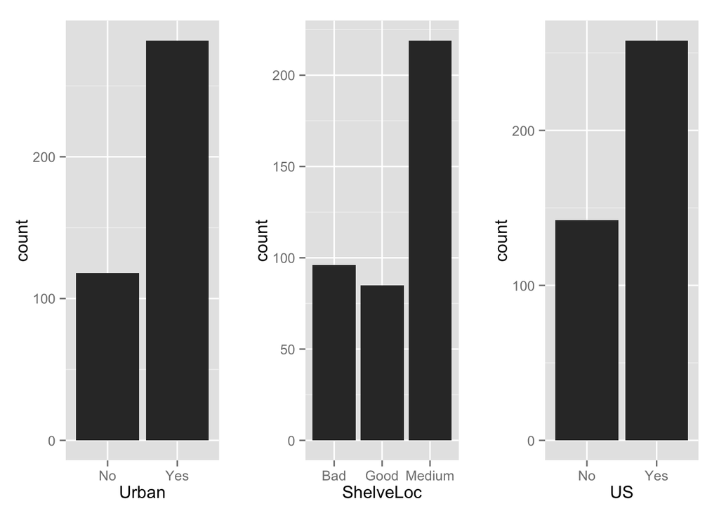

```r
p9= ggplot(Carseats, aes(x=Urban)) + geom_bar()
p10=ggplot(Carseats, aes(x=ShelveLoc)) + geom_bar()
p11=ggplot(Carseats, aes(x=US)) + geom_bar()

grid.arrange(p9,p10,p11, ncol=3)
```

# 3 -

Using a combination of correlation matrix of numeric variables and scatterplot matrix or combinations of scatterplots, which numeric variables seem to have a relationship with Sales of car seats?

```r
Carseatsnum= Carseats %>%
  select(1:6, 8:9)

cor(Carseatsnum, use="complete.obs", method="pearson")
```

```
##                   Sales   CompPrice       Income  Advertising   Population
## Sales        1.00000000  0.06407873  0.151950979  0.269506781  0.050470984
## CompPrice    0.06407873  1.00000000 -0.080653423 -0.024198788 -0.094706516
## Income       0.15195098 -0.08065342  1.000000000  0.058994706 -0.007876994
## Advertising  0.26950678 -0.02419879  0.058994706  1.000000000  0.265652145
## Population   0.05047098 -0.09470652 -0.007876994  0.265652145  1.000000000
## Price       -0.44495073  0.58484777 -0.056698202  0.044536874 -0.012143620
## Age         -0.23181544 -0.10023882 -0.004670094 -0.004557497 -0.042663355
## Education   -0.05195524  0.02519705 -0.056855422 -0.033594307 -0.106378231
##                   Price          Age    Education
## Sales       -0.44495073 -0.231815440 -0.051955242
## CompPrice    0.58484777 -0.100238817  0.025197050
## Income      -0.05669820 -0.004670094 -0.056855422
## Advertising  0.04453687 -0.004557497 -0.033594307
## Population  -0.01214362 -0.042663355 -0.106378231
## Price        1.00000000 -0.102176839  0.011746599
## Age         -0.10217684  1.000000000  0.006488032
## Education    0.01174660  0.006488032  1.000000000
```

It doesn’t seem as though any of the numeric variables have a strong relationship to sales of carseats.

# 4 -

Plot boxplots to visualize distribution of Sales across multiple levels of the three factor variables. Interpret how levels of a variable might be affecting sales.

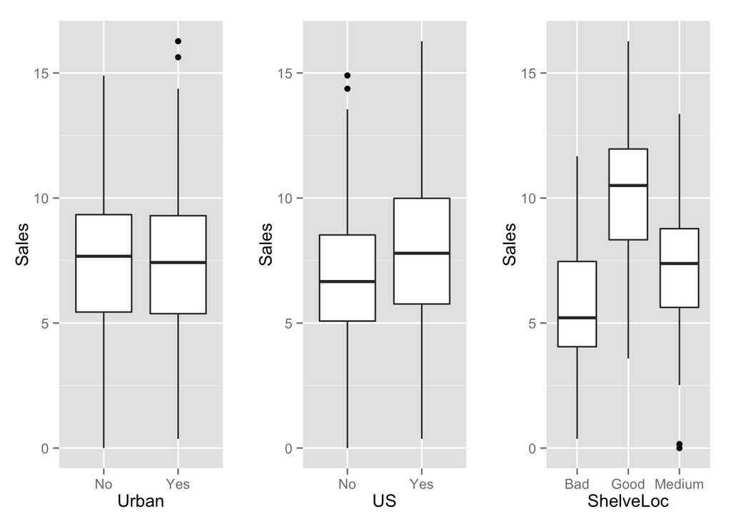

```r
p12= ggplot(Carseats, aes(x=Urban, y=Sales)) + geom_boxplot()
p13= ggplot(Carseats, aes(x=US, y=Sales)) + geom_boxplot()
p14=ggplot(Carseats, aes(x=ShelveLoc, y=Sales)) + geom_boxplot()

grid.arrange(p12,p13,p14, ncol=3)
```

Good shelf location indicates higher sales, as does being based in the US.

# 5 -

Develop a regression model to predict sales using all other variables, including factor variables. Which variables have an impact on sales? Interpret the coefficients of factor variables.

```r
reg= lm(Sales~CompPrice+Income+Advertising+Population+Price+ShelveLoc+Age+Education+Urban+US, data=Carseats)
summary(reg)
```

```
##
## Call:
## lm(formula = Sales ~ CompPrice + Income + Advertising + Population +
##     Price + ShelveLoc + Age + Education + Urban + US, data = Carseats)
##
## Residuals:
##     Min      1Q  Median      3Q     Max
## -2.8692 -0.6908  0.0211  0.6636  3.4115
##
## Coefficients:
##                   Estimate Std. Error t value Pr(>|t|)
## (Intercept)      5.6606231  0.6034487   9.380  < 2e-16 ***
## CompPrice        0.0928153  0.0041477  22.378  < 2e-16 ***
## Income           0.0158028  0.0018451   8.565 2.58e-16 ***
## Advertising      0.1230951  0.0111237  11.066  < 2e-16 ***
## Population       0.0002079  0.0003705   0.561    0.575
## Price           -0.0953579  0.0026711 -35.700  < 2e-16 ***
## ShelveLocGood    4.8501827  0.1531100  31.678  < 2e-16 ***
## ShelveLocMedium  1.9567148  0.1261056  15.516  < 2e-16 ***
## Age             -0.0460452  0.0031817 -14.472  < 2e-16 ***
## Education       -0.0211018  0.0197205  -1.070    0.285
## UrbanYes         0.1228864  0.1129761   1.088    0.277
## USYes           -0.1840928  0.1498423  -1.229    0.220
## ---
## Signif. codes:  0 '***' 0.001 '**' 0.01 '*' 0.05 '.' 0.1 ' ' 1
##
## Residual standard error: 1.019 on 388 degrees of freedom
## Multiple R-squared:  0.8734, Adjusted R-squared:  0.8698
## F-statistic: 243.4 on 11 and 388 DF,  p-value: < 2.2e-16
```

Interpreting the factor variables, medium shelf location means that it would increase sales by 1.95. Good shelf location increases sales by 4.85.

If the sale takes place in an urban area, sales increase by .12 compared to when a sale takes place in a non-urban area. However, this is not significant.

If the sale takes place in the United States, sales decrease by .18 compared to when a sale takes place in another country. However, this is not significant.

# 6 -

Use the ANOVA model to identify which variables have a significant impact on sales?

```r
aov(reg)
```

```
## Call:
##    aov(formula = reg)
##
## Terms:
##                 CompPrice    Income Advertising Population     Price
## Sum of Squares    13.0667   79.0734    219.3513     0.3824 1198.8669
## Deg. of Freedom         1         1           1          1         1
##                 ShelveLoc       Age Education     Urban        US
## Sum of Squares  1047.4750  217.3879    1.0503    1.2202    1.5671
## Deg. of Freedom         2         1         1         1         1
##                 Residuals
## Sum of Squares   402.8335
## Deg. of Freedom       388
##
## Residual standard error: 1.018936
## Estimated effects may be unbalanced
```

```r
summary(aov(reg))
```

```
##              Df Sum Sq Mean Sq  F value   Pr(>F)
## CompPrice     1   13.1    13.1   12.586 0.000436 ***
## Income        1   79.1    79.1   76.162  < 2e-16 ***
## Advertising   1  219.4   219.4  211.274  < 2e-16 ***
## Population    1    0.4     0.4    0.368 0.544276
## Price         1 1198.9  1198.9 1154.721  < 2e-16 ***
## ShelveLoc     2 1047.5   523.7  504.452  < 2e-16 ***
## Age           1  217.4   217.4  209.383  < 2e-16 ***
## Education     1    1.1     1.1    1.012 0.315135
## Urban         1    1.2     1.2    1.175 0.278989
## US            1    1.6     1.6    1.509 0.219975
## Residuals   388  402.8     1.0
## ---
## Signif. codes:  0 '***' 0.001 '**' 0.01 '*' 0.05 '.' 0.1 ' ' 1
```

```r
anova(reg)
```

```
## Analysis of Variance Table
##
## Response: Sales
##              Df  Sum Sq Mean Sq   F value    Pr(>F)
## CompPrice     1   13.07   13.07   12.5855 0.0004363 ***
## Income        1   79.07   79.07   76.1616 < 2.2e-16 ***
## Advertising   1  219.35  219.35  211.2741 < 2.2e-16 ***
## Population    1    0.38    0.38    0.3683 0.5442756
## Price         1 1198.87 1198.87 1154.7211 < 2.2e-16 ***
## ShelveLoc     2 1047.47  523.74  504.4519 < 2.2e-16 ***
## Age           1  217.39  217.39  209.3831 < 2.2e-16 ***
## Education     1    1.05    1.05    1.0117 0.3151346
## Urban         1    1.22    1.22    1.1753 0.2789892
## US            1    1.57    1.57    1.5094 0.2199750
## Residuals   388  402.83    1.04
## ---
## Signif. codes:  0 '***' 0.001 '**' 0.01 '*' 0.05 '.' 0.1 ' ' 1
```